# PracticalMachineLearning

Laica Noguera

August 16, 2019

# Practical Machine Learning Course Project

## The Dataset

### Library

```r
library(rpart)
```

```r
library(rpart.plot)
library(RColorBrewer)
library(rattle)
library(corrplot)
library(gbm)
library(caret)
library(randomForest)
```

## Getting, Cleaning and Exploring the dataset

As shown below there are 19622 observations and 160 variables in the Training dataset.

```r
train_data <- read.csv('./pml-training.csv', header=T)
valid_data <- read.csv('./pml-testing.csv', header=T)
dim(train_data)
```

```
## [1] 19622   160
```

### Cleaning

We remove the variables that contains missing values.

```r
trainData<- train_data[, colSums(is.na(train_data)) == 0]
validData <- valid_data[, colSums(is.na(valid_data)) == 0]
```

Here are the dimensions of the reduced dataset.

```r
dim(trainData)
```

```
## [1] 19622    93
```

```r
dim(validData)
```

```
## [1] 20 60
```

We’ll remove the first 7 variables because these are just variables that do not have a relevant prediction on our model.

```r
trainData <- trainData[, -c(1:7)]
validData <- validData[, -c(1:7)]
```

## Preparing the dataset

We’ll start with the train-test split. We’ll use 80-20 split.

```r
set.seed(1234)
inTrain <- createDataPartition(trainData$classe, p = 0.8, list = FALSE)
trainData <- trainData[inTrain, ]
testData <- trainData[-inTrain, ]
dim(trainData)
```

```
## [1] 15699    86
```

```r
dim(testData)
```

```
## [1] 3140   86
```

We’ll also remove variables that are near-zero-variance

```r
NZV <- nearZeroVar(trainData)
trainData <- trainData[, -NZV]
testData  <- testData[, -NZV]
dim(trainData)
```

```
## [1] 15699    53
```

```r
dim(testData)
```

```
## [1] 3140   53
```

We are now down to 53 variables, we’ll proceed to run a correlation plot to see the relationship between these variables using corrplot.

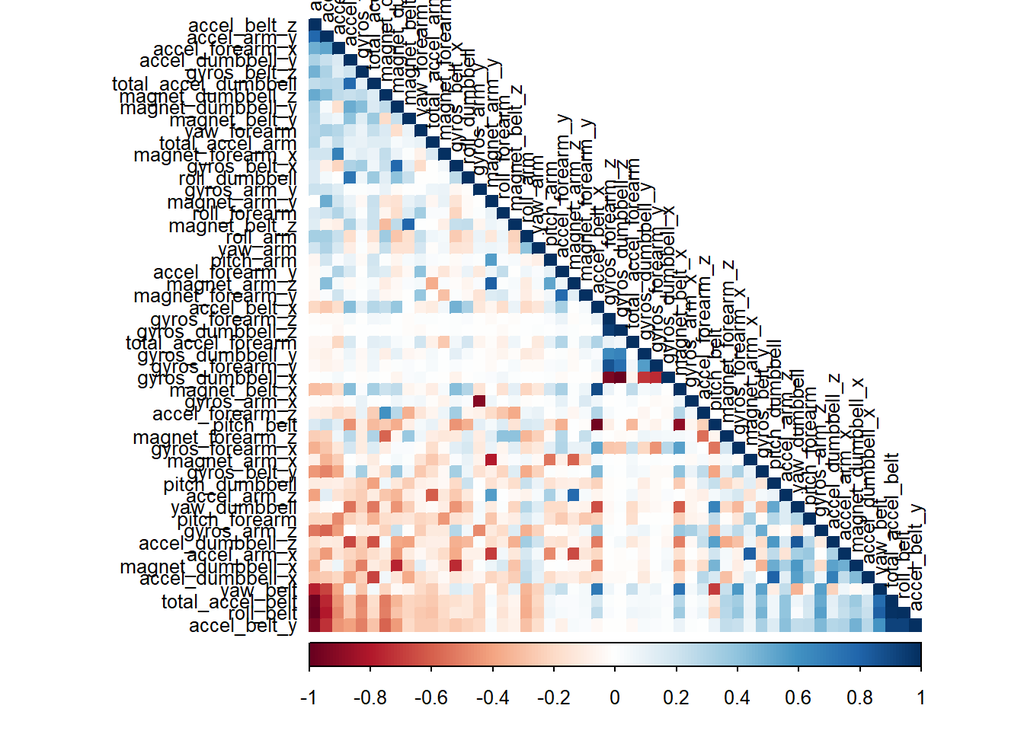

```r
cormat <- cor(trainData[, -53])
corrplot(cormat, order = "FPC", method = "color", type = "lower",
         tl.cex = 0.8, tl.col = rgb(0, 0, 0))
```

The correlated predictors (variables ) are those with a dark color intersection.

## Reduce Variables using Correlation Matrix

We’ll use the findCorrelation function to search for highly correlated attributes with a cut off equal to 0.75

```r
highlyCorrelated = findCorrelation(cormat, cutoff=0.75)
names(trainData)[highlyCorrelated]
```

```
##  [1] "accel_belt_z"      "roll_belt"         "accel_belt_y"
##  [4] "accel_arm_y"       "total_accel_belt"  "accel_dumbbell_z"
##  [7] "accel_belt_x"      "pitch_belt"        "magnet_dumbbell_x"
## [10] "accel_dumbbell_y"  "magnet_dumbbell_y" "accel_dumbbell_x"
## [13] "accel_arm_x"       "accel_arm_z"       "magnet_arm_y"
## [16] "magnet_belt_z"     "accel_forearm_y"   "gyros_forearm_y"
## [19] "gyros_dumbbell_x"  "gyros_dumbbell_z"  "gyros_arm_x"
```

## Modeling

We’ll use 3 algorithms to predict the outcome and compare the results.

1. Classification trees
2. Random forests
3. Generalized Boosted Model

## Classification Trees

[figure not shown]

```r
set.seed(12345)
decisionTreeMod1 <- rpart(classe ~ ., data=trainData, method="class")
fancyRpartPlot(decisionTreeMod1)
```

```r
predictTreeMod1 <- predict(decisionTreeMod1, testData, type = "class")
cmtree <- confusionMatrix(predictTreeMod1, testData$classe)
cmtree
```

```
## Confusion Matrix and Statistics
##
##           Reference
## Prediction   A   B   C   D   E
##          A 831 100   8  26   6
##          B  24 404  44  56  49
##          C  16  67 418  71  71
##          D   9  38  29 331  30
##          E  11  30  14  35 422
##
## Overall Statistics
##
##                Accuracy : 0.7662
##                  95% CI : (0.751, 0.781)
##     No Information Rate : 0.2838
##     P-Value [Acc > NIR] : < 2.2e-16
##
##                   Kappa : 0.7035
##
##  Mcnemar's Test P-Value : < 2.2e-16
##
## Statistics by Class:
##
##                      Class: A Class: B Class: C Class: D Class: E
## Sensitivity            0.9327   0.6322   0.8148   0.6378   0.7301
## Specificity            0.9378   0.9308   0.9144   0.9596   0.9649
## Pos Pred Value         0.8558   0.7002   0.6501   0.7574   0.8242
## Neg Pred Value         0.9723   0.9083   0.9620   0.9304   0.9406
## Prevalence             0.2838   0.2035   0.1634   0.1653   0.1841
## Detection Rate         0.2646   0.1287   0.1331   0.1054   0.1344
## Detection Prevalence   0.3092   0.1838   0.2048   0.1392   0.1631
## Balanced Accuracy      0.9352   0.7815   0.8646   0.7987   0.8475
```

```r
cmtree$overall['Accuracy']
```

```
## Accuracy
## 0.766242
```

## Random Forest

```r
controlRF <- trainControl(method="cv", number=3, verboseIter=FALSE)
modRF1 <- train(classe ~ ., data=trainData, method="rf", trControl=controlRF)
modRF1$finalModel
```

```
##
## Call:
##  randomForest(x = x, y = y, mtry = param$mtry)
##                Type of random forest: classification
##                      Number of trees: 500
## No. of variables tried at each split: 27
##
##         OOB estimate of  error rate: 0.63%
## Confusion matrix:
##      A    B    C    D    E class.error
## A 4457    5    1    0    1 0.001568100
## B   21 3008    8    1    0 0.009874918
## C    0   10 2717   11    0 0.007669832
## D    0    0   26 2543    4 0.011659541
## E    0    2    5    4 2875 0.003811504
```

### Test Model

```r
predictRF1 <- predict(modRF1, newdata=testData)
cmrf <- confusionMatrix(predictRF1, testData$classe)
cmrf
```

```
## Confusion Matrix and Statistics
##
##           Reference
## Prediction   A   B   C   D   E
##          A 891   0   0   0   0
##          B   0 639   0   0   0
##          C   0   0 513   0   0
##          D   0   0   0 519   0
##          E   0   0   0   0 578
##
## Overall Statistics
##
##                Accuracy : 1
##                  95% CI : (0.9988, 1)
##     No Information Rate : 0.2838
##     P-Value [Acc > NIR] : < 2.2e-16
##
##                   Kappa : 1
##
##  Mcnemar's Test P-Value : NA
##
## Statistics by Class:
##
##                      Class: A Class: B Class: C Class: D Class: E
## Sensitivity            1.0000   1.0000   1.0000   1.0000   1.0000
## Specificity            1.0000   1.0000   1.0000   1.0000   1.0000
## Pos Pred Value         1.0000   1.0000   1.0000   1.0000   1.0000
## Neg Pred Value         1.0000   1.0000   1.0000   1.0000   1.0000
## Prevalence             0.2838   0.2035   0.1634   0.1653   0.1841
## Detection Rate         0.2838   0.2035   0.1634   0.1653   0.1841
## Detection Prevalence   0.2838   0.2035   0.1634   0.1653   0.1841
## Balanced Accuracy      1.0000   1.0000   1.0000   1.0000   1.0000
```

```r
cmrf$overall['Accuracy']
```

```
## Accuracy
##        1
```

The accuracy rate using the random forest is very high: 1.00 but it might be due to overfitting.

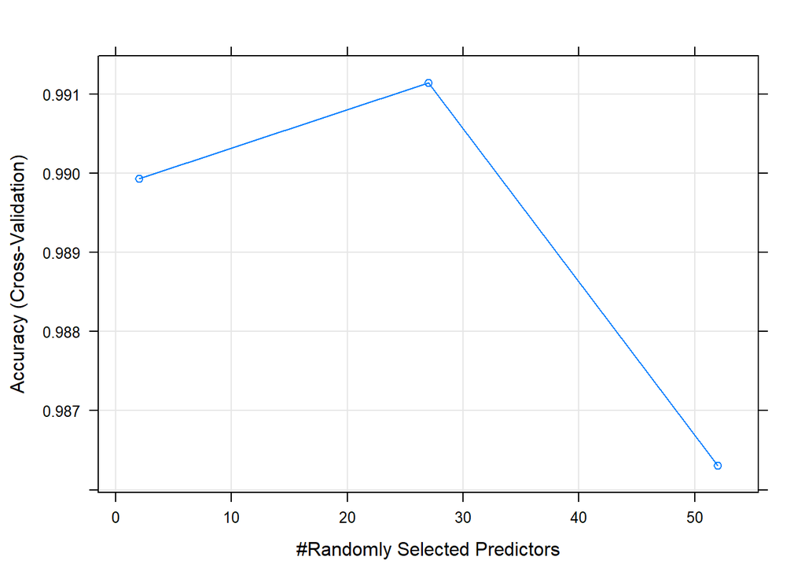

```r
plot(modRF1)
```

```r
set.seed(12345)
controlGBM <- trainControl(method = "repeatedcv", number = 5, repeats = 1)
modGBM  <- train(classe ~ ., data=trainData, method = "gbm", trControl = controlGBM, verbose = FALSE)
modGBM$finalModel
```

```
## A gradient boosted model with multinomial loss function.
## 150 iterations were performed.
## There were 52 predictors of which 52 had non-zero influence.
```

### Model Summary

```r
print(modGBM)
```

```
## Stochastic Gradient Boosting
##
## 15699 samples
##    52 predictor
##     5 classes: 'A', 'B', 'C', 'D', 'E'
##
## No pre-processing
## Resampling: Cross-Validated (5 fold, repeated 1 times)
## Summary of sample sizes: 12560, 12559, 12559, 12558, 12560
## Resampling results across tuning parameters:
##
##   interaction.depth  n.trees  Accuracy   Kappa
##   1                   50      0.7508118  0.6839840
##   1                  100      0.8222178  0.7749837
##   1                  150      0.8518378  0.8125261
##   2                   50      0.8557236  0.8171766
##   2                  100      0.9052159  0.8800236
##   2                  150      0.9304406  0.9119823
##   3                   50      0.8964893  0.8689837
##   3                  100      0.9406327  0.9248884
##   3                  150      0.9613979  0.9511619
##
## Tuning parameter 'shrinkage' was held constant at a value of 0.1
##
## Tuning parameter 'n.minobsinnode' was held constant at a value of 10
## Accuracy was used to select the optimal model using the largest value.
## The final values used for the model were n.trees = 150,
##  interaction.depth = 3, shrinkage = 0.1 and n.minobsinnode = 10.
```

## Test Model

```r
predictGBM <- predict(modGBM, newdata=testData)
cmGBM <- confusionMatrix(predictGBM, testData$classe)
cmGBM
```

```
## Confusion Matrix and Statistics
##
##           Reference
## Prediction   A   B   C   D   E
##          A 888  18   0   0   0
##          B   3 610  11   2   3
##          C   0  11 497  18   1
##          D   0   0   3 498   6
##          E   0   0   2   1 568
##
## Overall Statistics
##
##                Accuracy : 0.9748
##                  95% CI : (0.9687, 0.98)
##     No Information Rate : 0.2838
##     P-Value [Acc > NIR] : < 2.2e-16
##
##                   Kappa : 0.9681
##
##  Mcnemar's Test P-Value : NA
##
## Statistics by Class:
##
##                      Class: A Class: B Class: C Class: D Class: E
## Sensitivity            0.9966   0.9546   0.9688   0.9595   0.9827
## Specificity            0.9920   0.9924   0.9886   0.9966   0.9988
## Pos Pred Value         0.9801   0.9698   0.9431   0.9822   0.9947
## Neg Pred Value         0.9987   0.9885   0.9939   0.9920   0.9961
## Prevalence             0.2838   0.2035   0.1634   0.1653   0.1841
## Detection Rate         0.2828   0.1943   0.1583   0.1586   0.1809
## Detection Prevalence   0.2885   0.2003   0.1678   0.1615   0.1818
## Balanced Accuracy      0.9943   0.9735   0.9787   0.9781   0.9908
```

## Results

By comparing the accuracy rate values of the three models,the ‘Random Forest’ model is the winner. We’ll use it on the validation dataset.

```r
Results <- predict(modRF1, newdata=validData)
Results
```

```
##  [1] B A B A A E D B A A B C B A E E A B B B
## Levels: A B C D E
```